# Prosper Loan Data Exploration

## Preliminary Wrangling

This data set contains 113,937 loans with 81 variables on each loan, including loan amount, borrower rate (or interest rate), current loan status, borrower income, and many others.

```python
import numpy as np
import pandas as pd
import matplotlib.pyplot as plt
import seaborn as sb

%matplotlib inline
```

```python
# Loading data as a Pandas DataFrame
loan = pd.read_csv('prosperLoanData.csv')
```

```python
# High level overview
print(loan.shape)
print(loan.dtypes)
print(loan.head())
```

```
(113937, 81)
ListingKey                      object
ListingNumber                    int64
ListingCreationDate             object
CreditGrade                     object
Term                             int64
                                ...
PercentFunded                  float64
Recommendations                  int64
InvestmentFromFriendsCount       int64
InvestmentFromFriendsAmount    float64
Investors                        int64
Length: 81, dtype: object
                ListingKey  ListingNumber            ListingCreationDate  \
0  1021339766868145413AB3B         193129  2007-08-26 19:09:29.263000000
1  10273602499503308B223C1        1209647  2014-02-27 08:28:07.900000000
2  0EE9337825851032864889A          81716  2007-01-05 15:00:47.090000000
3  0EF5356002482715299901A         658116  2012-10-22 11:02:35.010000000
4  0F023589499656230C5E3E2         909464  2013-09-14 18:38:39.097000000

  CreditGrade  Term LoanStatus           ClosedDate  BorrowerAPR  \
0           C    36  Completed  2009-08-14 00:00:00      0.16516
1         NaN    36    Current                  NaN      0.12016
2          HR    36  Completed  2009-12-17 00:00:00      0.28269
3         NaN    36    Current                  NaN      0.12528
4         NaN    36    Current                  NaN      0.24614

   BorrowerRate  LenderYield  ...  LP_ServiceFees  LP_CollectionFees  \
0        0.1580       0.1380  ...         -133.18                0.0
1        0.0920       0.0820  ...            0.00                0.0
2        0.2750       0.2400  ...          -24.20                0.0
3        0.0974       0.0874  ...         -108.01                0.0
4        0.2085       0.1985  ...          -60.27                0.0

   LP_GrossPrincipalLoss  LP_NetPrincipalLoss LP_NonPrincipalRecoverypayments  \
0                    0.0                  0.0                             0.0
1                    0.0                  0.0                             0.0
2                    0.0                  0.0                             0.0
3                    0.0                  0.0                             0.0
4                    0.0                  0.0                             0.0

   PercentFunded  Recommendations InvestmentFromFriendsCount  \
0            1.0                0                          0
1            1.0                0                          0
2            1.0                0                          0
3            1.0                0                          0
4            1.0                0                          0

  InvestmentFromFriendsAmount Investors
0                         0.0       258
1                         0.0         1
2                         0.0        41
3                         0.0       158
4                         0.0        20

[5 rows x 81 columns]
```

```python
# Descriptive statistics for numeric variables
loan.describe()
```

|  | ListingNumber | Term | BorrowerAPR | BorrowerRate | LenderYield | EstimatedEffectiveYield | EstimatedLoss | EstimatedReturn | ProsperRating (numeric) | ProsperScore | ... | LP_ServiceFees | LP_CollectionFees | LP_GrossPrincipalLoss | LP_NetPrincipalLoss | LP_NonPrincipalRecoverypayments | PercentFunded | Recommendations | InvestmentFromFriendsCount | InvestmentFromFriendsAmount | Investors |
| --- | --- | --- | --- | --- | --- | --- | --- | --- | --- | --- | --- | --- | --- | --- | --- | --- | --- | --- | --- | --- | --- |
| count | 1.139370e+05 | 113937.000000 | 113912.000000 | 113937.000000 | 113937.000000 | 84853.000000 | 84853.000000 | 84853.000000 | 84853.000000 | 84853.000000 | ... | 113937.000000 | 113937.000000 | 113937.000000 | 113937.000000 | 113937.000000 | 113937.000000 | 113937.000000 | 113937.000000 | 113937.000000 | 113937.000000 |
| mean | 6.278857e+05 | 40.830248 | 0.218828 | 0.192764 | 0.182701 | 0.168661 | 0.080306 | 0.096068 | 4.072243 | 5.950067 | ... | -54.725641 | -14.242698 | 700.446342 | 681.420499 | 25.142686 | 0.998584 | 0.048027 | 0.023460 | 16.550751 | 80.475228 |
| std | 3.280762e+05 | 10.436212 | 0.080364 | 0.074818 | 0.074516 | 0.068467 | 0.046764 | 0.030403 | 1.673227 | 2.376501 | ... | 60.675425 | 109.232758 | 2388.513831 | 2357.167068 | 275.657937 | 0.017919 | 0.332353 | 0.232412 | 294.545422 | 103.239020 |
| min | 4.000000e+00 | 12.000000 | 0.006530 | 0.000000 | -0.010000 | -0.182700 | 0.004900 | -0.182700 | 1.000000 | 1.000000 | ... | -664.870000 | -9274.750000 | -94.200000 | -954.550000 | 0.000000 | 0.700000 | 0.000000 | 0.000000 | 0.000000 | 1.000000 |
| 25% | 4.009190e+05 | 36.000000 | 0.156290 | 0.134000 | 0.124200 | 0.115670 | 0.042400 | 0.074080 | 3.000000 | 4.000000 | ... | -73.180000 | 0.000000 | 0.000000 | 0.000000 | 0.000000 | 1.000000 | 0.000000 | 0.000000 | 0.000000 | 2.000000 |
| 50% | 6.005540e+05 | 36.000000 | 0.209760 | 0.184000 | 0.173000 | 0.161500 | 0.072400 | 0.091700 | 4.000000 | 6.000000 | ... | -34.440000 | 0.000000 | 0.000000 | 0.000000 | 0.000000 | 1.000000 | 0.000000 | 0.000000 | 0.000000 | 44.000000 |
| 75% | 8.926340e+05 | 36.000000 | 0.283810 | 0.250000 | 0.240000 | 0.224300 | 0.112000 | 0.116600 | 5.000000 | 8.000000 | ... | -13.920000 | 0.000000 | 0.000000 | 0.000000 | 0.000000 | 1.000000 | 0.000000 | 0.000000 | 0.000000 | 115.000000 |
| max | 1.255725e+06 | 60.000000 | 0.512290 | 0.497500 | 0.492500 | 0.319900 | 0.366000 | 0.283700 | 7.000000 | 11.000000 | ... | 32.060000 | 0.000000 | 25000.000000 | 25000.000000 | 21117.900000 | 1.012500 | 39.000000 | 33.000000 | 25000.000000 | 1189.000000 |

8 rows × 61 columns

```python
# Transforming categorical columns with order as ordinal categoric type step 1
ordinal_var_dict = {'LoanStatus': ['Current', 'Completed', 'Past Due (1-15 days)', 'Past Due (16-30 days)', 'Past Due (31-60 days)', 'Past Due (61-90 days)', 'Past Due (91-120 days)', 'Past Due (>120 days)','Cancelled', 'Defaulted',  'Chargedoff'],
                    'IncomeRange': ['Not employed', 'Not displayed', '$0', '$1-24,999', '$25,000-49,999 ', '$50,000-74,999', '$75,000-99,999', '$100,000+'],
                   'CreditGrade': ['AA', 'A', 'B', 'C', 'D', 'E', 'HR', 'NC']}
```

```python
# Transforming categorical columns with order as ordinal categoric type step 2
for var in ordinal_var_dict:
    ordered_var = pd.api.types.CategoricalDtype(ordered = True, categories = ordinal_var_dict[var])
    loan[var] = loan[var].astype(ordered_var)
```

```python
# Changing ListingCreationDate column as DateTime datatype
loan['ListingCreationDate'] = pd.to_datetime(loan['ListingCreationDate'])
```

```python
# Creating a new column "Year" from Listing CreationDate
loan['Year'] = pd.DatetimeIndex(loan['ListingCreationDate']).year
```

### What is/are the main feature(s) of interest in your dataset?

- What affects the borrower’s interest rate (`BorrowerRate`)?

### What features in the dataset do you think will help support your investigation into your feature(s) of interest?

From the borrowers' characteristics point of view, I expect below variables to be of interest:

1. the borrower's employment status and its duration
2. income range and stated monthly income
3. debt-to-income ratio
4. available bankcard credit
5. open credit lines
6. Prosper principal outstanding
7. credit grade or Prosper score
8. whether or not the borrower is a homeowner
9. ProsperPrincipalOutstanding
10. CurrentDelinquencies

From the loans' characteristics point of view, I think below features might be relevant indicators:

1. the number of terms
2. loan original amount
3. year in which the loans were started

## Univariate Exploration

I'll start by looking at the distribution of the main variable of interest: interest rate (`BorrowerRate`).

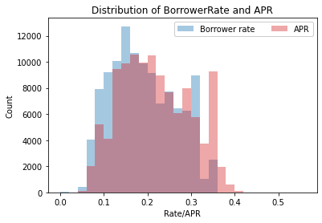

```python
# Borrower rate (and borrower APR) distribution
base_color_rate = sb.color_palette()[0]
base_color_apr = sb.color_palette()[3]
bins_rate = np.arange(0, loan.BorrowerRate.max()+0.05, 0.02)
bins_apr = np.arange(0, loan.BorrowerAPR.max()+0.05, 0.02)
plt.hist(data=loan, x='BorrowerRate', alpha=0.4, color=base_color_rate, bins=bins_rate);
plt.hist(data=loan, x='BorrowerAPR', alpha=0.4, color=base_color_apr, bins=bins_apr);
plt.legend(loc=1, ncol=2, framealpha=1, labels=['Borrower rate', 'APR']);
plt.xlabel('Rate/APR');
plt.ylabel('Count');
plt.title('Distribution of BorrowerRate and APR');
```

In the below cell I made two lists each representing a group of predictor variables of interest, the first consists of numeric variables and the second categorical ones. I will start with numeric features.

```python
# Groups of variables: separating numeric and categorical variables
num_var = ['BorrowerRate', 'BorrowerAPR', 'EmploymentStatusDuration', 'DebtToIncomeRatio', 'StatedMonthlyIncome', 'OpenCreditLines', 'MonthlyLoanPayment', 'AvailableBankcardCredit', 'LoanOriginalAmount', 'Investors', 'OpenRevolvingMonthlyPayment', 'TotalInquiries', 'CurrentCreditLines', 'CurrentDelinquencies']
categoric_var = ['EmploymentStatus', 'IsBorrowerHomeowner', 'IncomeRange', 'CreditGrade', 'Term', 'Year', 'ProsperScore', 'ListingCategory (numeric)', 'LoanStatus']
```

#### Numerical Variables

As an overview, I started by inspecting the distribution of numeric variables using a group of boxplots.

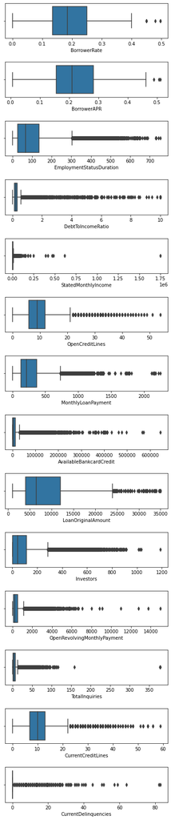

```python
# High-level overview on numeric variables of interest
fig, ax = plt.subplots(nrows=len(num_var), figsize = [6,25])
plt.subplots_adjust(hspace = 2)
base_color = sb.color_palette()[0]
fig.tight_layout(pad=3.0)

for count, i in enumerate(num_var):
    sb.boxplot(data=loan, x=i, color=base_color, ax=ax[count]);
```

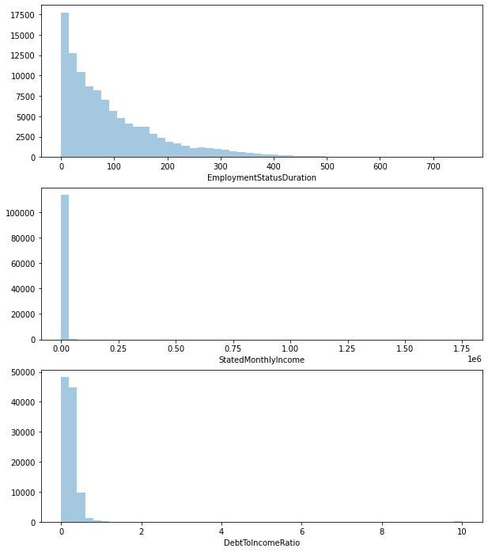

```python
# Distribution of EmploymentStatusDuration, StatedMonthlyIncome, DebtToIncomeRatio - before cleaning
fig = plt.figure(figsize=(10,12))

# EmploymentStatusDuration
plt.subplot(3,1,1)
sb.distplot(loan['EmploymentStatusDuration'], kde=False); # maybe change this, because this var is used in log transformation

# StatedMonthlyIncome
plt.subplot(3,1,2)
#bins = np.arange(0, loan.StatedMonthlyIncome.max()+1, 5)
sb.distplot(loan['StatedMonthlyIncome'], kde=False);

# DebtToIncomeRatio
plt.subplot(3,1,3)
sb.distplot(loan['DebtToIncomeRatio'], kde=False);
```

##### Removing Missing Values and Outliers

```python
# Number of missing values in concerned numeric variables
for i in num_var:
    print(i, loan[i].isna().sum())
```

```
BorrowerRate 0
BorrowerAPR 25
EmploymentStatusDuration 7625
DebtToIncomeRatio 8554
StatedMonthlyIncome 0
OpenCreditLines 7604
MonthlyLoanPayment 0
AvailableBankcardCredit 7544
LoanOriginalAmount 0
Investors 0
OpenRevolvingMonthlyPayment 0
TotalInquiries 1159
CurrentCreditLines 7604
CurrentDelinquencies 697
```

```python
loan.dropna(how='any', subset=num_var, inplace=True)
```

```python
# original shape: (113937, 81)
loan.shape
```

```
(97886, 82)
```

```python
# List of columns that have extreme high outliers
outliers = ['StatedMonthlyIncome', 'DebtToIncomeRatio', 'CurrentDelinquencies', 'AvailableBankcardCredit', 'Investors', 'OpenRevolvingMonthlyPayment', 'TotalInquiries']
```

```python
# Removing outliers
for i in outliers:
    cut_off = np.quantile(loan[i], .95)
    loan = loan[loan[i] <= cut_off]
```

```python
loan.shape
```

```
(69553, 82)
```

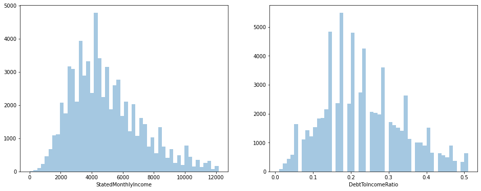

```python
fig = plt.figure(figsize=(16, 6))

# Stated monthly income distribution
plt.subplot(1,2,1)
#bins = np.arange(0, loan.StatedMonthlyIncome.max()+1, 100)
sb.distplot(loan['StatedMonthlyIncome'], kde=False);

# Distribution of borrowers' DebtToIncomeRatio
plt.subplot(1,2,2)
sb.distplot(loan['DebtToIncomeRatio'], kde=False);
```

Re-plotting the overview:

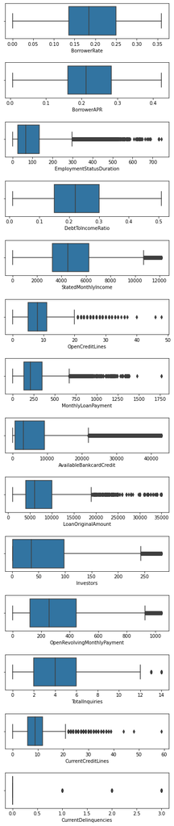

```python
# High-level overview on numeric variables of interest - after removing missing data and some of the outliers
fig, ax = plt.subplots(nrows=len(num_var), figsize = [6,25])
plt.subplots_adjust(hspace = 2)
base_color = sb.color_palette()[0]
fig.tight_layout(pad=3.0)

for count, i in enumerate(num_var):
    sb.boxplot(data=loan, x=i, color=base_color, ax=ax[count]);
```

As can be seen above, most extreme high outliers have been removed.

##### Log Transformation

- `EmploymentStatusDuration`
- `AvailableBankcardCredit`
- `ProsperPrincipalOutstanding`
- `Investors`
- `LoanOriginalAmount`

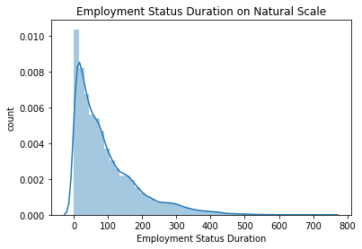

```python
# Borrowers' employment status duration distribution in number of months
sb.distplot(loan['EmploymentStatusDuration']);
plt.xlabel('Employment Status Duration');
plt.ylabel('count');
plt.title('Employment Status Duration on Natural Scale');
```

The distribution is right skewed with a long tail, thus the next step introduces a log scale.

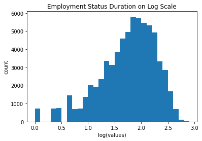

```python
# Direct data transform: EmploymentStatusDuration
base_color = sb.color_palette()[0]
log_data = np.log10(loan.EmploymentStatusDuration)
bins = np.arange(0, log_data.max()+0.1, 0.1)
plt.hist(log_data, color = base_color, bins=bins);

# Ticks
#ticks = [1, 10, 30, 100, 300, 1000]
#plt.xticks(ticks, ticks)

# Annotations
plt.xlabel('log(values)');
plt.ylabel('count');
plt.title('Employment Status Duration on Log Scale');
plt.show()
```

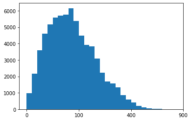

```python
# Alternative way to transform EmploymentStatusDuration
def sqrt_trans(x, inverse = False):
    """ transformation helper function """
    if not inverse:
        return np.sqrt(x)
    else:
        return x ** 2

data = loan.EmploymentStatusDuration
bin_edges = np.arange(0, sqrt_trans(data.max())+1, 1);
plt.hist(data.apply(sqrt_trans), bins = bin_edges)
tick_locs = np.arange(0, sqrt_trans(data.max())+10, 10)
plt.xticks(tick_locs, sqrt_trans(tick_locs, inverse = True).astype(int));
plt.title('Employment Status Duration on Log Scale')
```

Prosper's borrowers' current employment status duration distribution is different, with direct data transformation, the data is left skewed, however, with x-axis transformation it is slightly right skewed.

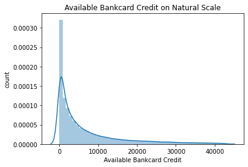

```python
# Available bankcard credit distribution
loan.AvailableBankcardCredit.value_counts()
sb.distplot(loan.AvailableBankcardCredit);
plt.xlabel('Available Bankcard Credit');
plt.ylabel('count');
plt.title('Available Bankcard Credit on Natural Scale');
```

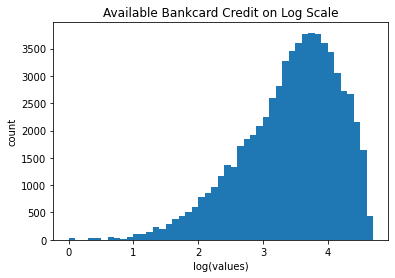

```python
# Log transformation - AvailableBankcardCredit
base_color = sb.color_palette()[0]
log_credit = np.log10(loan.AvailableBankcardCredit)
bins = np.arange(0, log_credit.max()+0.1, 0.1)
plt.hist(log_credit, color = base_color, bins=bins);

# Annotation
plt.xlabel('log(values)');
plt.ylabel('count');
plt.title('Available Bankcard Credit on Log Scale');
```

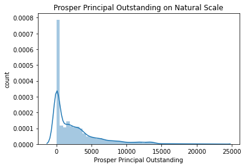

```python
# Principal outstanding amount distribution
loan.ProsperPrincipalOutstanding.value_counts()
sb.distplot(loan.ProsperPrincipalOutstanding);
plt.xlabel('Prosper Principal Outstanding');
plt.ylabel('count');
plt.title('Prosper Principal Outstanding on Natural Scale');
```

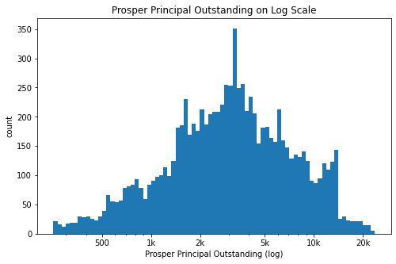

```python
# there's a long tail in the distribution, so let's put it on a log scale instead
log_binsize = 0.025
bins = 10 ** np.arange(2.4, np.log10(loan['ProsperPrincipalOutstanding'].max())+log_binsize,
                       log_binsize) # Why 2.4?
plt.figure(figsize=[8, 5])
plt.hist(data = loan, x = 'ProsperPrincipalOutstanding', bins = bins)
# Data transformation
plt.xscale('log')
# Ticks
plt.xticks([500, 1e3, 2e3, 5e3, 1e4, 2e4], [500, '1k', '2k', '5k', '10k', '20k'])
plt.xlim = ([1, 20000])
# Annotation
plt.xlabel('Prosper Principal Outstanding (log)');
plt.ylabel('count');
plt.title('Prosper Principal Outstanding on Log Scale');
plt.show()
```

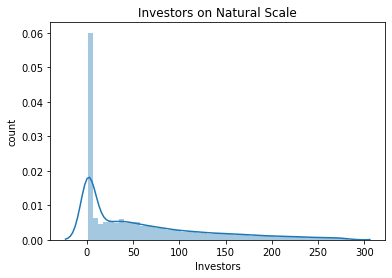

```python
# Number of investors
sb.distplot(loan.Investors);
plt.xlabel('Investors');
plt.ylabel('count');
plt.title('Investors on Natural Scale');
```

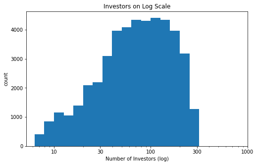

```python
# Log transformation - number of Investors
plt.figure(figsize=[8, 5])
bin_edges = 10 ** np.arange(0.8, np.log10(loan.Investors.max())+0.1, 0.1)
plt.hist(data = loan, x = 'Investors', bins = bin_edges)
plt.xscale('log')
# Ticks
tick_locs = [10, 30, 100, 300, 1000]
plt.xticks(tick_locs, tick_locs)
#plt.xlim([1, loan.Investors.max()])

# Annotation
plt.xlabel('Number of Investors (log)');
plt.ylabel('count');
plt.title('Investors on Log Scale');
plt.show()
```

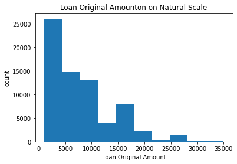

```python
# Original loan amount - numeric and discrete
plt.hist(data=loan, x='LoanOriginalAmount');
plt.xlabel('Loan Original Amount');
plt.ylabel('count');
plt.title('Loan Original Amounton on Natural Scale');
```

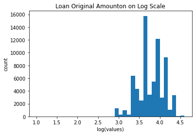

```python
# Transforming LoanOriginalAmount
base_color = sb.color_palette()[0]
log_amount = np.log10(loan.LoanOriginalAmount)
bins = np.arange(1, log_amount.max()+0.1, 0.1)
plt.hist(log_amount, color = base_color, bins=bins);
# Ticks
#plt.xticks([1, 2, 5], [1, 2, 5])
#plt.xlim([1, log_amount.max()+0.1])
# Annotation
plt.xlabel('log(values)');
plt.ylabel('count');
plt.title('Loan Original Amounton on Log Scale');
```

#### Categorical Variables

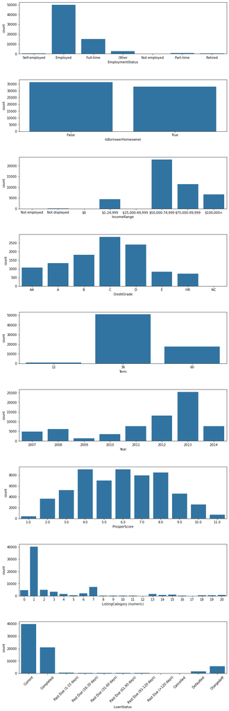

```python
# High-level overview
base_color = sb.color_palette()[0]
fig, ax = plt.subplots(nrows=len(categoric_var), figsize = [10,30])
fig.tight_layout(pad=2.0)
plt.subplots_adjust(hspace = 0.5)
# Plotting
for count, i in enumerate(categoric_var):
    sb.countplot(data=loan, x=i, ax=ax[count], color=base_color);
    plt.xticks(rotation='45');
```

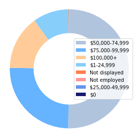

```python
# Income range composition among borrowers
from matplotlib import cm
n_range = loan['IncomeRange'].value_counts()
colors = ['lightsteelblue','#66b3ff','#ffcc99','lightskyblue','coral', '#ff9999', 'cornflowerblue', 'midnightblue']
labels = n_range.index

# Plotting
ax, texts = plt.pie(n_range, wedgeprops={'width':0.4}, startangle=90, counterclock=False, colors=colors);

# Annotation and plot adjustment
plt.axis('square');
plt.legend(ax, labels, loc='center right')
plt.tight_layout()
plt.show()
```

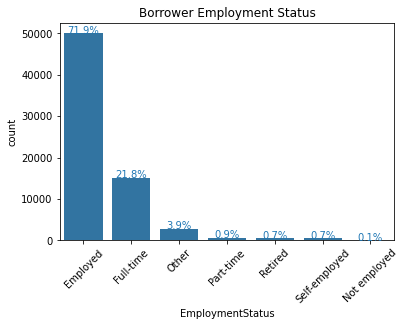

```python
# Employment status in relative frequencies
base_color = sb.color_palette()[0]
g_order = loan['EmploymentStatus'].value_counts().index
sb.countplot(data = loan, x = 'EmploymentStatus', color = base_color, order=g_order);

# Annotations
n_points = loan.shape[0]
status_counts = loan['EmploymentStatus'].value_counts()
locs, labels = plt.xticks() # get the current tick locations and labels

# Loop through each pair of locations and labels
for loc, label in zip(locs, labels):

    # get the text property for the label to get the correct count
    count = status_counts[label.get_text()]
    pct_string = '{:0.1f}%'.format(100*count/n_points)

    # print the annotation just below the top of the bar
    plt.text(loc, count-8, pct_string, ha = 'center', color = base_color)
    plt.xticks(rotation='45');
plt.title('Borrower Employment Status');
```

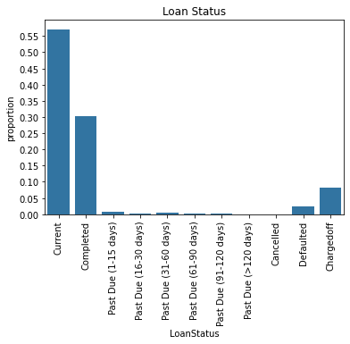

```python
# Loan status bar chart
n_points = loan.shape[0]
max_count = loan['LoanStatus'].value_counts().max()
max_prop = max_count / n_points

# Generate tick mark locations and names
tick_props = np.arange(0, max_prop, 0.05)
tick_names = ['{:0.2f}'.format(v) for v in tick_props]

# Plotting
base_color = sb.color_palette()[0]
sb.countplot(data = loan, x = 'LoanStatus', color = base_color)
plt.xticks(rotation='90')
plt.yticks(tick_props * n_points, tick_names);
plt.ylabel('proportion');
plt.title('Loan Status');
```

Other variables that might be of interest.

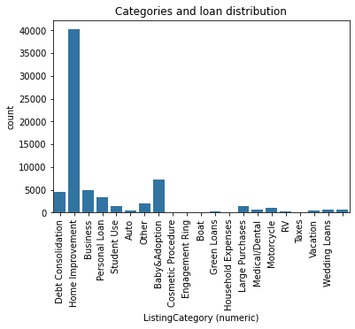

```python
# ListingCategory
ax = sb.countplot(data=loan, x='ListingCategory (numeric)', color=base_color);
listing_cat = ['Debt Consolidation', 'Home Improvement', 'Business', 'Personal Loan', 'Student Use', 'Auto', 'Other', 'Baby&Adoption', 'Cosmetic Procedure', 'Engagement Ring', 'Boat', 'Green Loans', 'Household Expenses', 'Large Purchases', 'Medical/Dental', 'Motorcycle', 'RV', 'Taxes', 'Vacation', 'Wedding Loans']
ax.set_xticklabels(listing_cat);
plt.xticks(rotation='90');
plt.title('Categories and loan distribution');
```

### Of the features you investigated, were there any unusual distributions? Did you perform any operations on the data to tidy, adjust, or change the form of the data? If so, why did you do this?

When investigating the numeric variables, a number of outliers were identified. For clarity, most of them were removed from the dataset together with missing values in these numeric variables.

## Bivariate Exploration

To start off with, I want to look at the pairwise correlations present between features in the data.

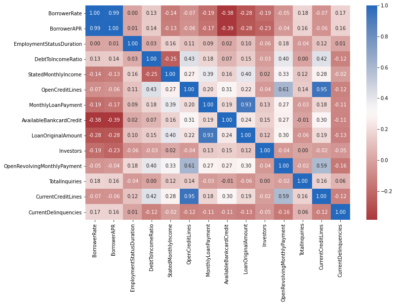

```python
# correlation heatmap among numeric variables
plt.figure(figsize=(12,8))
sb.heatmap(loan[num_var].corr(), cmap='vlag_r', annot=True, fmt='0.2f');
```

```python
loan.shape
```

```
(69553, 82)
```

`BorrowerRate` and `BorrowerAPR` columns do not show any strong correlation to any other numeric variables. However, among predictor variables, there are positive correlation between:

1. `OpenRevolvingPayment` v.s. `OpenCreditLines`
2. `CurrentCreditLines` v.s. `OpenCreditLines` v.s. `OpenRevolvingMonthlyPayment`

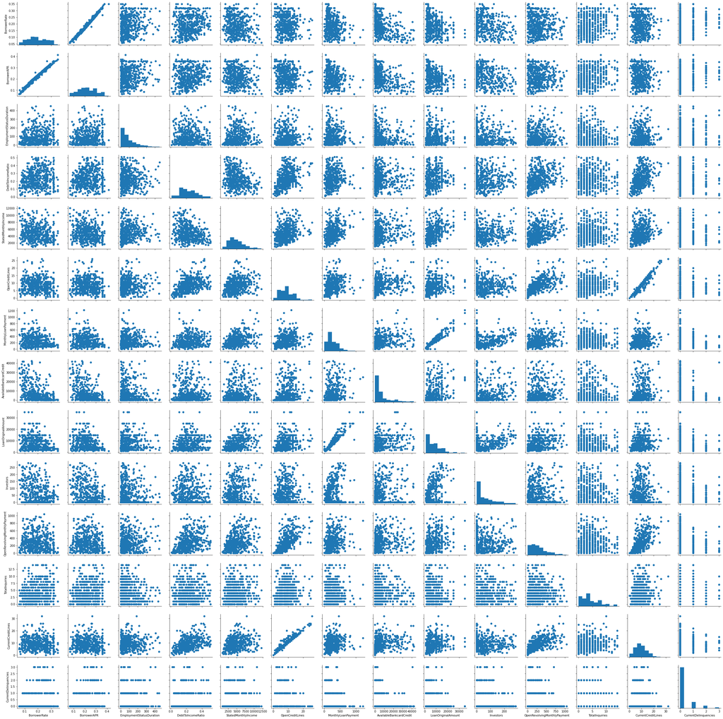

```python
# Matrices for numeric variables witn sampled data
samples = np.random.choice(loan.shape[0], 500, replace = False)
loan_samp = loan.iloc[samples,:]  # difference between .iloc and .loc

# Plotting
g = sb.PairGrid(data=loan_samp, vars=num_var);
g = g.map_offdiag(plt.scatter);
g.map_diag(plt.hist);
```

From the PairGrid above, no direct correlations are identified between other variables with either BorrowerRate or BorrowerAPR. Since log transformation was applied to `EmploymentStatusDuration`, `AvailableBankcardCredit`, `ProsperPrincipalOutstanding`, `Investors`, and `LoanOriginalAmount` variables, I follow up with their visualisation with BorrowerRate at logarithm scales.

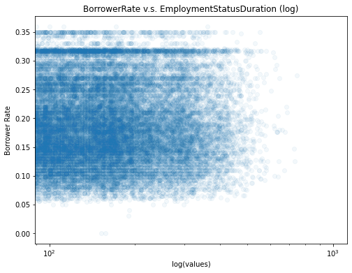

```python
# BorrowerRate v.s. EmploymentStatusDuration correlation on log scale
plt.figure(figsize = [8, 6])
plt.scatter(data = loan, x = 'EmploymentStatusDuration', y = 'BorrowerRate', alpha = 1/20);

# Log transformation
plt.xscale('log')

# Ticks and axis limit
#tick_locs = [1e0, 3e0, 1e1, 3e1, 1e2, 3e2, 1e3]
#plt.xticks(tick_locs, tick_locs)
#plt.xlim([1, 1e3])

# Annotation
plt.ylabel('Borrower Rate');
plt.xlabel('log(values)');
plt.title('BorrowerRate v.s. EmploymentStatusDuration (log)');
plt.show()
```

There is no clear correlation between interest rates and employment status duration.

```python
log_credit.max()
```

[output not shown]

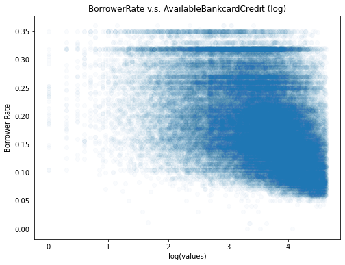

```python
# BorrowerRate v.s. AvailableBankcardCredit correlation on log scale
plt.figure(figsize = [8, 6])

# Log transformation
log_credit = np.log10(loan.AvailableBankcardCredit)
bins_x = np.arange(0, log_credit.max()+0.1, 0.1)
plt.scatter(data = loan, x = log_credit, y = 'BorrowerRate', alpha = 1/40);
plt.xlabel('log(values)');
# Ticks and axis limit
#tick_locs = [5e2, 1e3, 2e3, 5e3, 1e4, 2e4, 5e4]
#tick_marks = [500, 1000, 2000, 5000, 10000, 20000, 50000]
#plt.xticks(tick_locs, tick_marks)
#plt.xlim([0, log_credit.max()+0.1])

# Annotation
plt.ylabel('Borrower Rate');
plt.title('BorrowerRate v.s. AvailableBankcardCredit (log)');
```

There is a negative correlation between interest rates and available bank card credits.

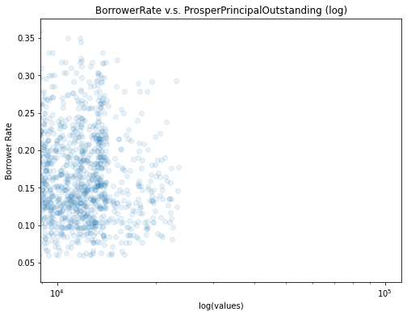

```python
# BorrowerRate v.s. ProsperPrincipalOutstanding correlation on log scale
plt.figure(figsize = [8, 6])
ax = plt.scatter(data = loan, x = 'ProsperPrincipalOutstanding', y = 'BorrowerRate', alpha = 1/10);
plt.xscale('log')

# Ticks
#tick_locs = [10, 3e1, 1e2, 3e2, 1e3, 3e3, 1e4, 3e4]
#plt.xticks(tick_locs, tick_locs);
#plt.xlim([0, 3e4])

# Annotation
plt.ylabel('Borrower Rate')
plt.xlabel('log(values)')
plt.title('BorrowerRate v.s. ProsperPrincipalOutstanding (log)');
```

There is no clear direct correlation between interest rates and available outstanding principal payments.

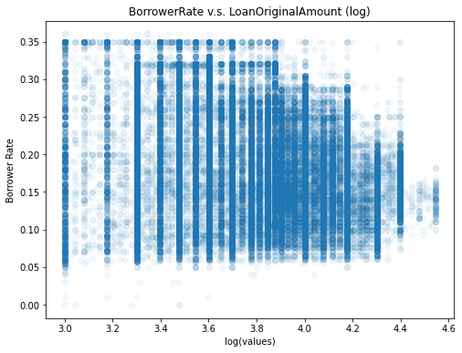

```python
# BorrowerRate v.s. LoanOriginalAmount correlation on log scale
plt.figure(figsize = [8, 6])
log_data = np.log10(loan.LoanOriginalAmount)
bins_x = np.arange(0, log_data.max()+0.1, 0.1)
plt.scatter(data = loan, x = log_data, y = 'BorrowerRate', alpha = 1/20);
plt.xlabel('log(values)')

# Ticks
#tick_locs = [1e1, 3e1, 1e3, 3e2, 1e3, 3e3, 1e4]
#plt.xticks(tick_locs, tick_locs)
#plt.xlim([1, 1e4])

# Annotation
plt.ylabel('Borrower Rate')
plt.title('BorrowerRate v.s. LoanOriginalAmount (log)');
```

There is no clear direct correlation between interest rates and loan original amounts.

##### Pair relationship between BorrowerRate and categorical variables

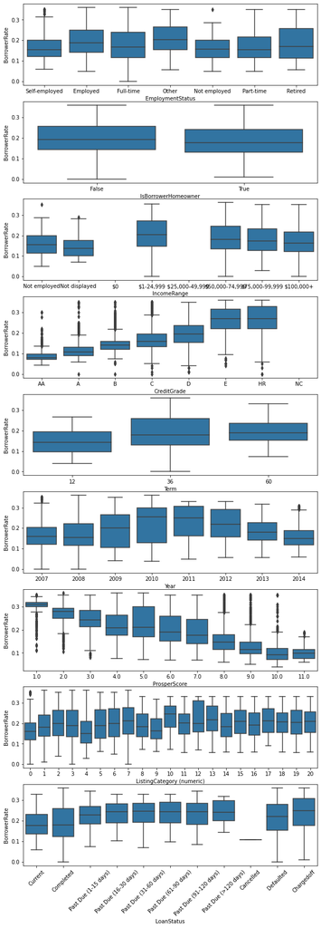

```python
# Boxplots for relationships - numeric and categorical data investigation - variables about borrowers
base_color = sb.color_palette()[0]
fig, ax = plt.subplots(nrows = len(categoric_var), figsize = [10,30])

for count, i in enumerate(categoric_var):
    sb.boxplot(data=loan, x=i, y='BorrowerRate', ax=ax[count], color=base_color)
    plt.xticks(rotation='45')
```

**Borrowers characteristics** Homeowners pay slightly less interest rate than non-homeowners in general. Among people who have certain income, the higher the income, the lower the interest rate. For data before 2009, credit grade is a good (secondary) indicator for interest rate: the better the grade (AA is the best), the lower the interest. Also, the standard deviation is narrower as the grade gets better. Another similar variable is `ProsperScore`, the higher the score, the lower the interest rate.  
**Loans characteristics** Interest rate has positive correlation with the number of `Term`, the longer a loan takes, the higher the interest rate, presumably because longer terms means more risks for lenders.  
`LoanStatus` can also be another indicator to rates, as those with a past due has slightly higher interest rate.

#### Relationships between Prediction Variables Investigation

From the above graphs, `ProsperScore` is a clear secondary (as it's generated based on other variables) predictor, thus I will follow up with its correlations with the underlying key variables (according to [Prosper website](https://www.prosper.com/plp/general-prosper_score/)):

- Number of inquiries on the credit bureau
- Number of delinquent accounts on the credit bureau
- Credit card utilization on the credit bureau
- Number of recently opened trades on the credit bureau
- Debt to income ratio
- Loan payment performance on prior Prosper loans

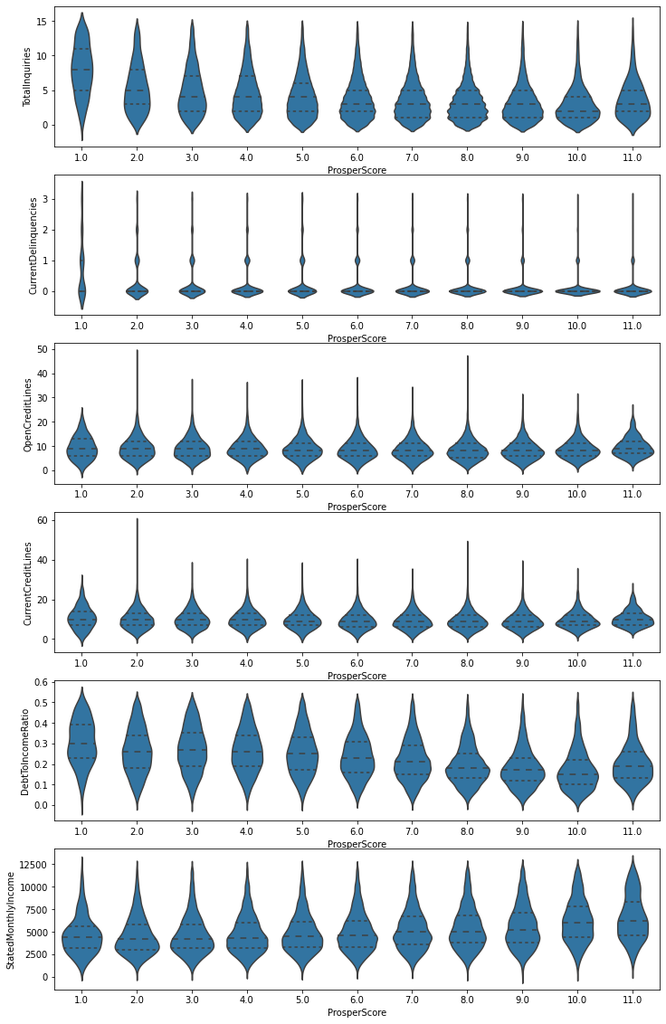

```python
# ProsperScore and its underlying variables, plus other numeric variables that describe the borrower's financial situation - Part I
score_var_num = ['TotalInquiries', 'CurrentDelinquencies', 'OpenCreditLines', 'CurrentCreditLines', 'DebtToIncomeRatio', 'StatedMonthlyIncome']
# Plotting
base_color=sb.color_palette()[0]
fig, ax = plt.subplots(nrows=len(score_var_num), figsize = [12,20])
for count, i in enumerate(score_var_num):
    sb.violinplot(data=loan, x='ProsperScore', y=i, color=base_color, inner='quartile', ax=ax[count]);
```

The higher the ProsperScore, the lower the standard deviations of `CurrentDelinquencies`.  
In the next step, I will look into these variables' relationship with interest rate.

```
No handles with labels found to put in legend.
No handles with labels found to put in legend.
```

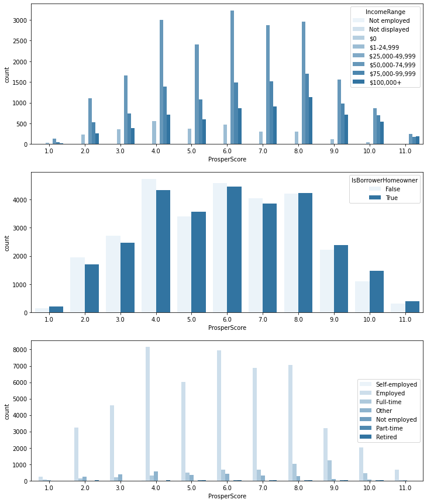

```python
# ProsperScore and categorical variables that describe the borrower's financial situation - Part II
score_var_cat = ['IncomeRange', 'IsBorrowerHomeowner', 'EmploymentStatus']
# Plotting
base_color=sb.color_palette()[0]
fig, ax = plt.subplots(nrows=len(score_var_cat), figsize = [12,15])
for count, i in enumerate(score_var_cat):
    sb.countplot(data=loan, x='ProsperScore', hue=i, color=base_color, ax=ax[count]);
    plt.legend(loc='right');
```

As `ProsperScore` increases, the percentage of borrowers in higher income range also increases. Same trend goes for `IsBorrowerHomeowner`, the higher the score, the more likely the borrower has a home.

```
No handles with labels found to put in legend.
```

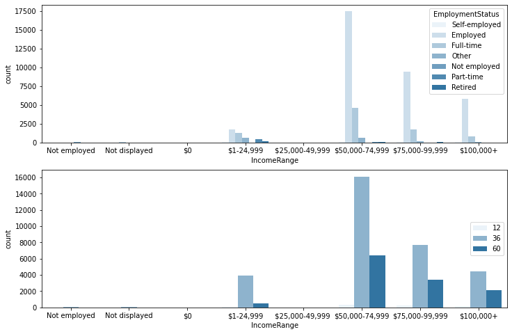

```python
# Potential correlations between IncomeRange and a) EmploymentStatus, b) Term
correlated_var = ['EmploymentStatus', 'Term']
base_color=sb.color_palette()[0]
fig, ax = plt.subplots(nrows=len(correlated_var), figsize = [12,8])

for count, i in enumerate(correlated_var):
    sb.countplot(data=loan, x='IncomeRange', hue=i, color=base_color, ax=ax[count]);
    plt.legend(loc='right');
```

The majority of loan borrowers have an income range of \$50,000\-\\$100,000+. The most popular number of terms is 36, while the least popular for all groups is 12. (As income range increases, borrowers are more likely to take loans with more terms, presumably with more security into long-term financial prospects. Since previously shown number of terms increases as interet rate increases, this higher proportion of 60-term loans among higher income groups does not explain the reason why higher income goes in tandem with lower interest rate.)  
It's difficult to gauge the relationship among the type of employment status, income range and connect them to interet rates, thus I will investigate further in the Multivariate Exploration.

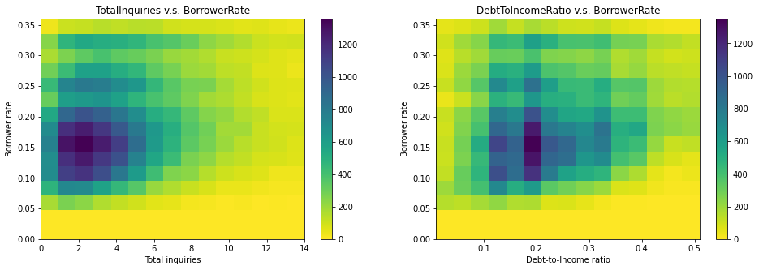

```python
# TotalInquiries v.s. BorrowerRate
plt.figure(figsize = [16, 5])
plt.subplot(1, 2, 1)
plt.hist2d(data = loan, x = 'TotalInquiries', y = 'BorrowerRate', cmap='viridis_r', bins=15);#, cmin=100, bins=[bins_x, bins_y]
plt.colorbar();
# Annotations
plt.xlabel('Total inquiries')
plt.ylabel('Borrower rate')
plt.title('TotalInquiries v.s. BorrowerRate');

# DebtToIncomeRatio v.s. BorrowerRate
plt.subplot(1, 2, 2)
plt.hist2d(data = loan, x = 'DebtToIncomeRatio', y = 'BorrowerRate', cmap='viridis_r', bins=15); #, bins=[bins_x, bins_y]);
plt.colorbar();
# Annotations
plt.xlabel('Debt-to-Income ratio')
plt.ylabel('Borrower rate')
plt.title('DebtToIncomeRatio v.s. BorrowerRate');

plt.show()
```

Although the above two variables are considered key indicators for Prosper score which is strongly correlated to interest rate, these two variables do not show clear correlation with interest rate directly. There is a peak in the interest rate from 0.10 to 0.20, and a debt-to-income ratio of range 0.1 to 0.2.

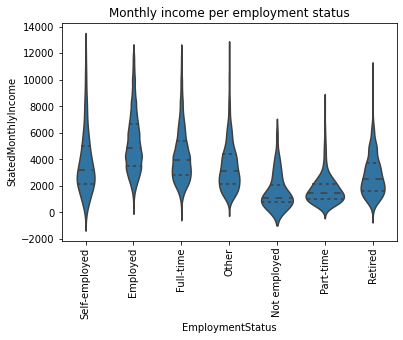

```python
# Monthly income per employment status
sb.violinplot(data=loan, x='EmploymentStatus', y='StatedMonthlyIncome', color=base_color, inner='quartile');
plt.xticks(rotation='90');
plt.title('Monthly income per employment status');
```

## Multivariate Exploration

The main thing I want to explore in this part of the analysis is how the measures of a borrowers' financial status play into the relationship between Interest rate and loans' own characteristics, for example, `Term`, `LoanStatus`, which has shown clear correlation with rates in the previous step.  
The indicators of financial status include: `IsBorrowerHomeowner`, `DebtToIncomeRatio`, `IncomeRange` or `StatedMonthlyIncome`, and `AvailableBankcardCredit`.

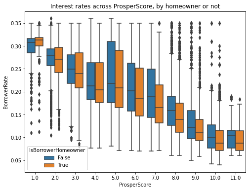

```python
# Interest rates across ProsperScore, by homeowner or not
fig = plt.figure(figsize=(8,6))
sb.boxplot(data=loan, x='ProsperScore', y='BorrowerRate', hue='IsBorrowerHomeowner');
plt.title('Interest rates across ProsperScore, by homeowner or not');
```

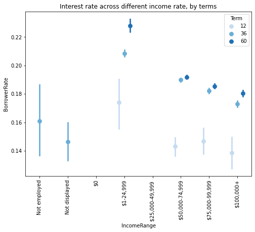

```python
# Interest rates across terms, by income ranges
fig = plt.figure(figsize = [8,6])
ax = sb.pointplot(data = loan, x = 'IncomeRange', y = 'BorrowerRate', hue = 'Term',
           palette = 'Blues', linestyles = '', dodge = 0.4)
plt.title('Interest rate across different income rate, by terms')
ax.set_yticklabels([],minor = True)
plt.xticks(rotation='90')
plt.show();
```

Within each income range group, the rate increases as amount of terms increases; overall, for the same amount of terms, people with higher income are able to be granted lower interest rate.

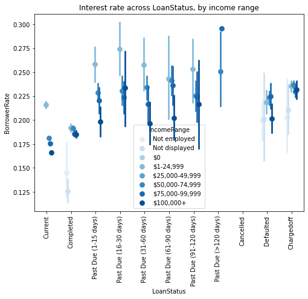

```python
#  Interest rates across different loan statuses, by income range
fig = plt.figure(figsize = [8,6])
ax = sb.pointplot(data = loan, x = 'LoanStatus', y = 'BorrowerRate', hue = 'IncomeRange', palette = 'Blues', linestyles = '', dodge = 0.4)
plt.title('Interest rate across LoanStatus, by income range')
ax.set_yticklabels([],minor = True)
plt.xticks(rotation='90')
plt.show();
```

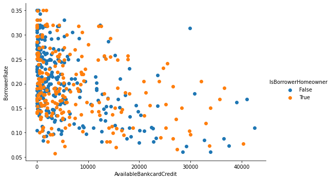

```python
# Available bankcard credit v.s. interest rate, by home owner or not
# Sampling data points from original DataFrame
samples = np.random.choice(loan.shape[0], 500, replace = False)
loan_samp = loan.iloc[samples,:]
# Plotting 1
g = sb.FacetGrid(data = loan_samp, hue = 'IsBorrowerHomeowner', height = 5, aspect=1.5);
g.map(plt.scatter, 'AvailableBankcardCredit', 'BorrowerRate');
g.add_legend();
```

The data points are clustered to the left, note that I used log transformation for credit data previously, I will modify the plot in a log scale.

```python
log_data.max()
```

```
4.544068044350276
```

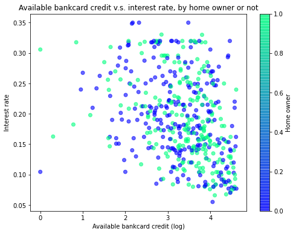

```python
# Log transformation on credit data
log_data = np.log10(loan_samp.AvailableBankcardCredit)
# Plotting
fig = plt.figure(figsize = [8,6]);
plt.scatter(data = loan_samp, x = log_data, y = 'BorrowerRate', c = 'IsBorrowerHomeowner',
            cmap = 'winter', alpha=0.6);
# Ticks
#ticks = [1e1, 2e1, 5e1, 1e3, 2e3, 5e3, 1e4, 2e4, 3e4, 5e4]
#plt.xticks(ticks, ticks)
#plt.xlim([1, 5e4])

# Annotation and colors
plt.title('Available bankcard credit v.s. interest rate, by home owner or not');
plt.xlabel('Available bankcard credit (log)');
plt.ylabel('Interest rate');
# Legend?
plt.colorbar(label='Home owner')

plt.show()
```

Despite whether a borrower is home owner or not, the amount of available bankcard credits show a negative correlation to interest rates.

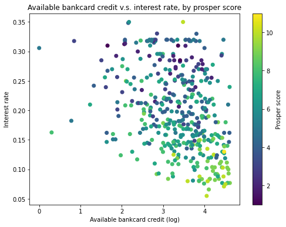

```python
# Available bankcard credit v.s. interest rate, by prosper score
# Log transformation
log_data = np.log10(loan_samp.AvailableBankcardCredit)
# Plotting 2
fig = plt.figure(figsize = [8,6]);
plt.scatter(data = loan_samp, x = log_data, y = 'BorrowerRate', c = 'ProsperScore', cmap = 'viridis', alpha=1);
# Annotation and colors
plt.title('Available bankcard credit v.s. interest rate, by prosper score');
plt.xlabel('Available bankcard credit (log)');
plt.ylabel('Interest rate');
# Legend
plt.colorbar(label='Prosper score')

plt.show()
```

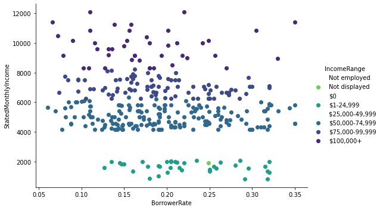

```python
# FacetGrid for interest rate across different monthly income, by group of income ranges
g = sb.FacetGrid(data = loan_samp, hue = 'IncomeRange',
                 size = 5, aspect=1.5, palette='viridis_r');
g.map(plt.scatter, 'BorrowerRate', 'StatedMonthlyIncome');
g.add_legend();
plt.show()
```

If stated monthly income is lower than 4000, it's less likely for a borrower to have a rate of lower than 0.10.

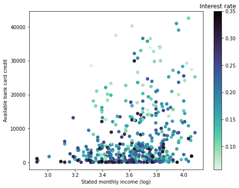

```python
# Available bankcard credit v.s. stated monthly income, by interest rate
fig = plt.figure(figsize=(8, 6))
log_data = np.log10(loan_samp.StatedMonthlyIncome)
plt.scatter(data = loan_samp, x = log_data, y = 'AvailableBankcardCredit',
            c = 'BorrowerRate', cmap = 'mako_r');
plt.xlabel('Stated monthly income (log)')
plt.ylabel('Available bank card credit')
clb = plt.colorbar();
clb.ax.set_title('Interest rate');
```

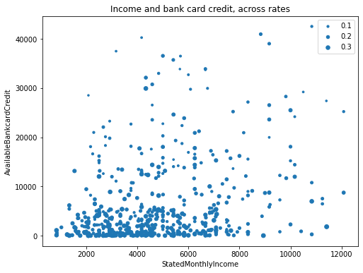

```python
# StatedMonthlyIncome v.s. AvailableBankcardCredit, BorrowerRate
fig = plt.figure(figsize=(8,6))
p = 100.0 * loan_samp['BorrowerRate']
plt.scatter(data = loan_samp, x = 'StatedMonthlyIncome', y = 'AvailableBankcardCredit', s = p.values)
# Annotation
plt.title('Income and bank card credit, across rates')
plt.xlabel('StatedMonthlyIncome')
plt.ylabel('AvailableBankcardCredit')
# dummy series for adding legend
sizes = [0.1, 0.2, 0.3]
base_color = sb.color_palette()[0]
legend_obj = []
for s in sizes:
    legend_obj.append(plt.scatter([], [], s = 100*s, color = base_color))
plt.legend(legend_obj, sizes);
```

**Other potential relationships**

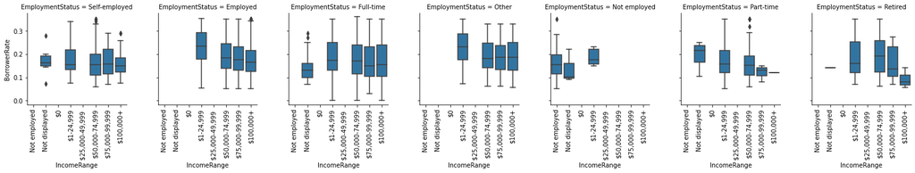

```python
# Interest rates across income ranges, by each employment status
g = sb.FacetGrid(data = loan, col = 'EmploymentStatus');
g.map(sb.boxplot, 'IncomeRange', 'BorrowerRate');
g.set_xticklabels(rotation='90');
```

**Compare trends within each group** Overall, there is a similar trend of a decreasing interest rate as income rises.  
**Comparison across groups** The interest rates are in similar range across different groups.

### Talk about some of the relationships you observed in this part of the investigation. Were there features that strengthened each other in terms of looking at your feature(s) of interest?

After understanding that interest rate rises with the longer a loan's due date passed, or its number of terms increases, I extended my investigation of borrowers' financial situations and loans' characteristics. On one hand, I looked into the impact of borrowers' personal situations on the existing correlations between rates and loan types and statuses. On the other hand, as ProsperScore seems to be the strongest indirect indicator, I tried to link its underlying variables directly to interest rates, including `DebtToIncomeRatio` and `TotalInquiries` etc.

**Less terms and better statuses of loans means lower rates, but it's an borrower's financial situation that eventually sets the rate. Borrowers with higher bankcard credits and income range, home owners have more chance of receiving lower interest rates.**  
The negative correlation between income range and interest rate (as observed in the bivariate exploration stage) is confirmed in multivariate exploration. Previously, I found `Term` has a positive correlation with rates, but it was not clear how borrowers' income ranges' (`IncomeRange`) negative correlation with rates affect this correlation. In multivariate exploration, it's observed that within each income range group, the rate increases as amount of terms increases, **but, for the same amount of terms, people with higher income are able to be granted lower interest rate, despite number of `Term`**.

Similarly, although `ProsperScore` has a negative correlation with rates, but whether the borrowers are **home owners (`IsBorrowerHomeowner`)still proven to decide whether they can get lower interest rate**, i.e., a homeowner who has the same score as a non-homeowner can enjoy lower rates.  
Also, interest rates decrease as income ranges increase, despite of different `LoanStatus`.

### Were there any interesting or surprising interactions between features?

Borrowers with high ProsperScore mostly have high bankcard credits (`AvailableBankcardCredits`), and enjoy lowest interest rates (below 0.15). However, among lower Prosper scores, bank card credit's role is less important.